# Globálne otepľovanie

**Dáta v súbore globalwarm.txt sú odchýlky od priemernej teploty (za roky 1961-1990) merané za obdobie 1900-1997**

#### Načítanie dát o globálnom otepľovaní

```r
globalwarm <- read.delim2("globalwarm.txt", header=FALSE)
str(globalwarm)
```

```
## 'data.frame':    98 obs. of  1 variable:
##  $ V1: num  -0.13 -0.22 -0.37 -0.44 -0.49 -0.37 -0.3 -0.5 -0.52 -0.49 ...
```

#### Načítanie premenných

```r
globaldata<-globalwarm$V1
t<-1900:1997
```

#### Lineárny trend

```r
fitGlobData <- lm(globaldata~t)
coefficients(fitGlobData)
```

```
##   (Intercept)             t
## -12.186407628   0.006209475
```

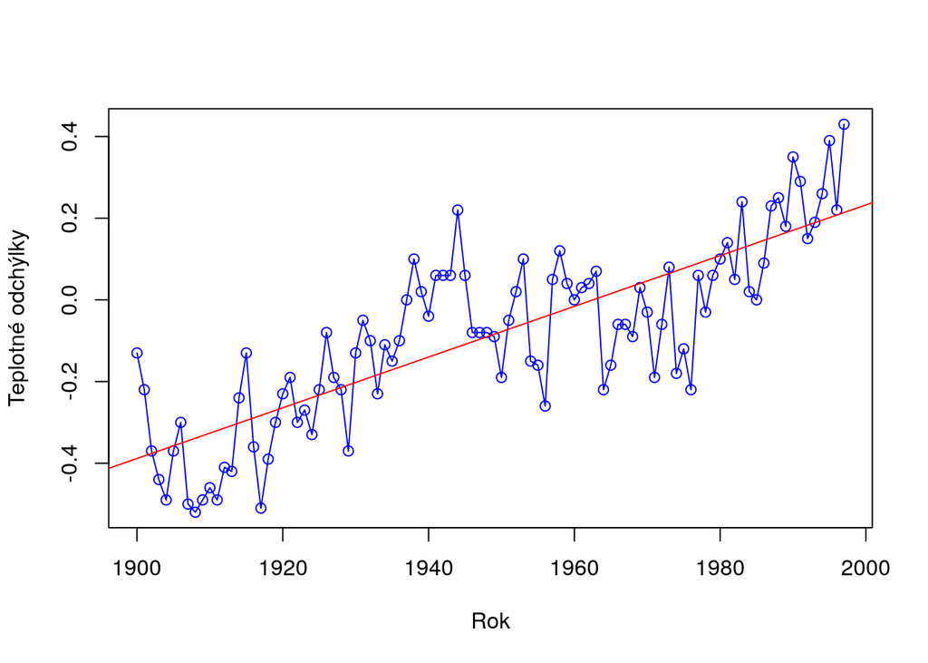

```r
plot(t, globaldata, type = 'o', col='blue', xlab = 'Rok', ylab = 'Teplotné odchýlky')
abline(fitGlobData, col = 'red')
```

#### Reziduá

```r
resGlobData <- residuals(fitGlobData)
plot(t, resGlobData, type = 'o', col='blue', xlab = 'Rok', ylab = 'Reziduá')
fitResData <- lm(resGlobData~t)
coefficients(fitResData)
```

```
##   (Intercept)             t
##  2.468420e-17 -6.708237e-21
```

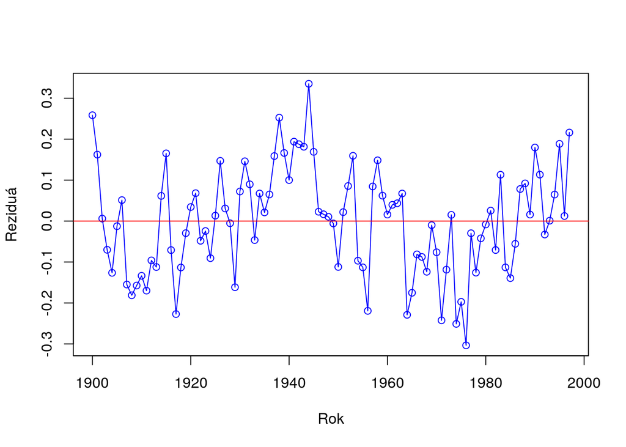

```r
abline(fitResData, col= 'red')
```

Vidíme, že naše dáta ešte stále nie sú úplne stacionárne. Zrejme ešte obsahujú nejakú sezónnu zložku. Tú potrebujeme odstrániť. Vieme, že klasický dekompozičný model (aditívny) predpokladá náhodný proces v tvare $X_t = m_t + s_t + Y_t = \mu_t + Y_t$. Potrebujeme sa zbaviť časti $\mu_t$, ktorá závisí od času.

#### Odstránenie sezónnej zložky diferencovaním

Z reziduí vytvoríme nový ČR: $Y_{t2}-Y_{t1},\quad Y_{t3}-Y_{t2},\ldots,Y_{tn}-Y_{tn-1}$

#### Znázornenie diferencií reziduí

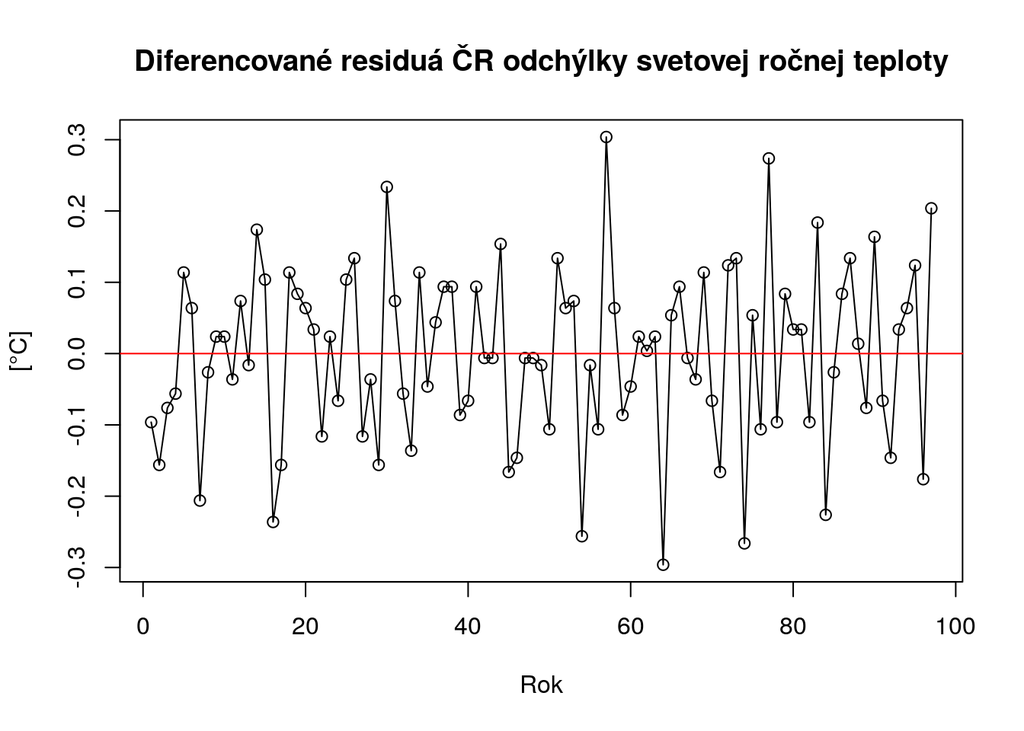

```r
plot(diff(resGlobData), type = 'o', main = 'Diferencované residuá ČR odchýlky svetovej ročnej teploty', ylab = '[°C]', xlab = 'Rok')
abline(0,0,col='red')
```

#### Znázornenie diferencií pôvodného ČR

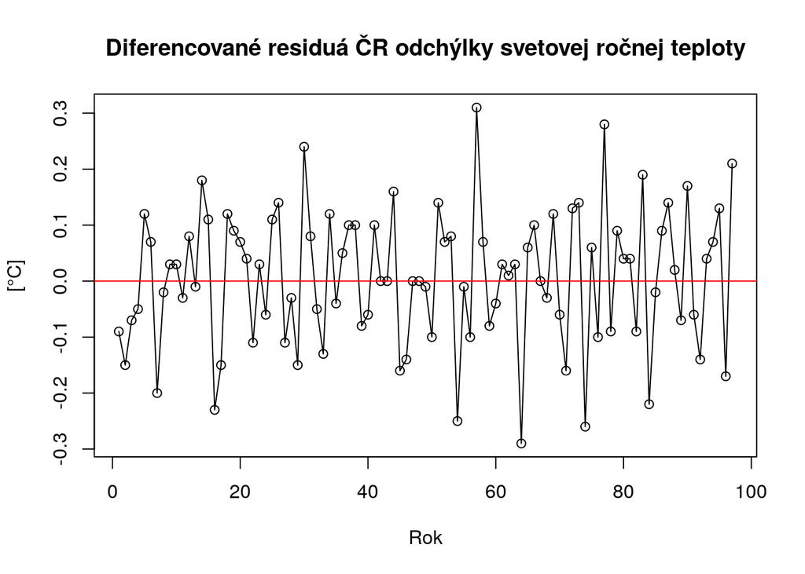

```r
plot(diff(globaldata), type = 'o', main = 'Diferencované residuá ČR odchýlky svetovej ročnej teploty', ylab = '[°C]', xlab = 'Rok')
abline(0,0,col='red')
```

Diferencovanie odstránilo nielen sezónnu zložku ale aj lineárny trend! Porovnaním však môžeme zistiť, že medzi poslednými dvoma grafmi je malý posun o aditívnu konštantu.

**Úloha:**

- Dokážte, že operátor diferencovania eliminuje lineárny trend ČR.

Majme dáta v tvare $X_t = m_t + Y_t = a + bt + Y_t$. Diferenciu sme si definovali ako $\Delta X_t = X_t - X_{t-1} = a + bt + Y_t - (a+b(t-1)+Y_{t-1}) = b + Y_{t} - Y_{t-1} = b + \Delta Y_t$. Koeficient lineárneho trendu sme v našom prípade vypočítali a mal hodnotu $b = 0.006$. Preto bol posun tak malý.

Záver: Diferencovanie odstráni lineárny trend a sezónnu zložku, až na aditívnu konštatnu, ktorá je rovná smernici $b$.

$m_t = \sum_{k=0}^{p}c_kt^k$, kde $t = 0, \pm 1, \pm 2, ...$

$\Delta X_t = X_t - X_{t-1} = \sum_{k=0}^pc_kt^k + Y_t - \sum_{k=0}^{p}c_k(t-1)^k - Y_{t-1}= \sum_{k=0}^{p}c_k(t^k-(t-1)^k + \Delta Y_t$

Spravíme substitúciu: $ (t-1)^k = t^k - kt^{k-1} + t^{k-2} + … + (-1)^k$

Keby sme spravili ďalšiu diferenciu, tak sa zbavíme ďalšieho rádu. $\Delta^pX_t = p^1c_p + \Delta^pY_t$ dôkaz cez (MI).

**Úloha:**

- Aplikujte diferenciu na ČR s polynomickým trendom
  $$m_t=\sum_{k=0}^{p}c_k \cdot t^k, \quad t=0,\pm 1,\pm 2,\ldots$$
  a urobte záver.
- Aký operátor je potrebné použiť, aby sme eliminovali polynomický trend na nenulovú konštantu a aký na nulovú konštantu?